## Redes Neurais e Algoritmos de Aprendizado Profundo

- Gabriel Bertolini

# Relatório Técnico: Classificação de Sons de Animais com CNN

## 1. Definição do Problema

O objetivo deste projeto é desenvolver um modelo de **Deep Learning** capaz de identificar automaticamente a espécie de um animal com base em gravações de áudio.

Este é um problema de **Classificação Multiclasse**, onde o modelo recebe um sinal de áudio bruto (arquivo `.wav`), processa suas características espectrais e prediz a qual das categorias (animais) aquele som pertence.

**Aplicações Práticas:**

- Monitoramento de vida selvagem e biodiversidade.
- Sistemas de segurança e vigilância em áreas rurais.
- Ferramentas educacionais e de catalogação automática.

## 2. Sobre o Banco de Dados (Dataset)

Os dados utilizados provêm de uma coleção de arquivos de áudio organizados em subdiretórios, onde o nome da pasta representa a classe (rótulo) do animal.

- **Fonte:** Arquivos de áudio `.wav` (dataset local/Kaggle).
- **Estrutura:** Áudios de curta duração variada.
- **Quantidade:** Aproximadamente 650 amostras originais.
- **Pré-processamento:**
  - Conversão para Mono (1 canal).
  - Padronização de duração (Padding/Truncating).
  - **Data Augmentation:** Aplicação de ruído e alteração de tom (Pitch Shift) no conjunto de treino para aumentar a robustez do modelo.

## 3. Variáveis e Engenharia de Atributos (Features)

Redes Neurais não "ouvem" som, elas analisam números. Para isso, transformamos o áudio bruto em representações matemáticas visuais.

### A Variável de Entrada (X)

Utilizamos **MFCCs (Mel-Frequency Cepstral Coefficients)** como entrada para a Rede Neural.

### A Variável Alvo (y)

A variável alvo é a **Espécie do Animal**. Foi aplicado *One-Hot Encoding* para transformar os nomes em vetores binários para a classificação.

## Classes

O modelo foi treinado para identificar as seguintes **13 espécies**:

1. **Aslan** (Leão)
2. **Bear** (Urso)
3. **Cat** (Gato)
4. **Chicken** (Galinha/Galo)
5. **Cow** (Vaca)
6. **Dog** (Cachorro)
7. **Dolphin** (Golfinho)
8. **Donkey** (Burro)
9. **Elephant** (Elefante)
10. **Frog** (Sapo)
11. **Horse** (Cavalo)
12. **Monkey** (Macaco)
13. **Sheep** (Ovelha)

## 5. Metodologia de Modelagem

Para resolver o problema, utilizamos uma **Rede Neural Convolucional (CNN)**, arquitetura estado-da-arte para processamento de imagens e espectrogramas.

- **Camadas Convolucionais (Conv2D):** Extraem padrões visuais dos MFCCs (ex: linhas horizontais para sons harmônicos, linhas verticais para percussivos).
- **Pooling (MaxPooling2D):** Reduz a dimensionalidade e foca nas características mais importantes.
- **Dropout:** Desativa neurônios aleatoriamente durante o treino para evitar *Overfitting* (decoreba).
- **Output:** Camada densa com ativação `Softmax`, retornando a probabilidade de o som pertencer a cada uma das 13 classes.

```
Lendo arquivos e metadados...

========================================
 RESUMO ESTATÍSTICO DOS DADOS
========================================
Total de Arquivos: 650
Total de Classes : 13
Classes: ['Aslan' 'Bear' 'Cat' 'Chicken' 'Cow' 'Dog' 'Dolphin' 'Donkey' 'Elephant'
 'Frog' 'Horse' 'Monkey' 'Sheep']
----------------------------------------
Duração Média   : 2.7675 segundos
Duração Mínima  : 0.1965 segundos
Duração Máxima  : 54.2929 segundos
Desvio Padrão   : 3.2834 segundos
========================================
```

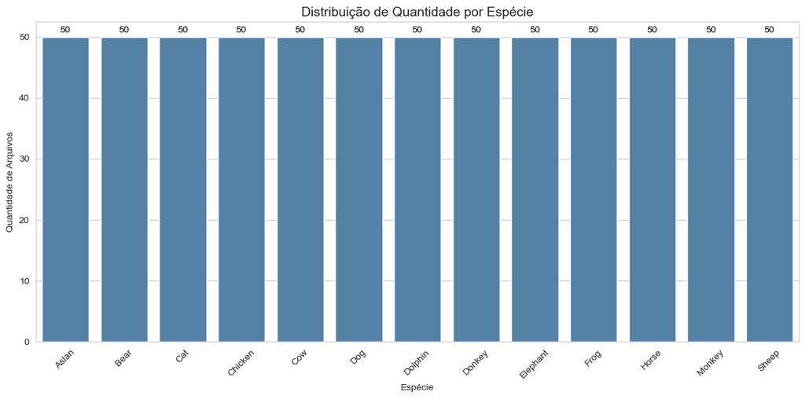

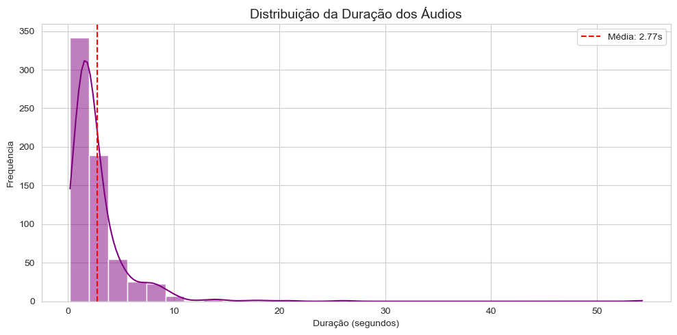

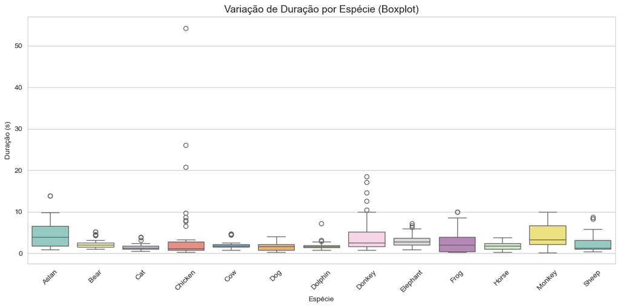

```python
# descritiva

import os
import sys
import numpy as np
import pandas as pd
import matplotlib.pyplot as plt
import seaborn as sns
import soundfile as sf
import warnings

# Configurações visuais
sns.set_style("whitegrid")
warnings.filterwarnings('ignore')

DATA_ROOT_LOCAL = r"C:\Users\berto\OneDrive\Documentos\neural networks\dados_animal_temp\Animal-Soundprepros"

data = []

if not os.path.exists(DATA_ROOT_LOCAL):
    print(" Erro: Pasta não encontrada.")
    sys.exit()

# Lista as pastas
class_folders = [d for d in os.listdir(DATA_ROOT_LOCAL) if os.path.isdir(os.path.join(DATA_ROOT_LOCAL, d))]

print("Lendo arquivos e metadados...")

# Loop de leitura
for class_label in class_folders:
    class_path = os.path.join(DATA_ROOT_LOCAL, class_label)
    for filename in os.listdir(class_path):
        if filename.lower().endswith('.wav'):
            full_path = os.path.join(class_path, filename)

            try:
                # sf.info lê apenas o cabeçalho (rápido)
                info = sf.info(full_path)
                data.append({
                    'label': class_label,
                    'filename': filename,
                    'full_path': full_path,
                    'duration': info.duration,
                    'samplerate': info.samplerate
                })
            except Exception as e:
                print(f" Erro ao ler {filename}: {e}")

df = pd.DataFrame(data)

if len(df) == 0:
    print(" Nenhum dado encontrado.")
    sys.exit()

# --- ESTATÍSTICAS ---
print("\n" + "="*40)
print(" RESUMO ESTATÍSTICO DOS DADOS")
print("="*40)
print(f"Total de Arquivos: {len(df)}")
print(f"Total de Classes : {df['label'].nunique()}")
print(f"Classes: {df['label'].unique()}")
print("-" * 40)
print(f"Duração Média   : {df['duration'].mean():.4f} segundos")
print(f"Duração Mínima  : {df['duration'].min():.4f} segundos")
print(f"Duração Máxima  : {df['duration'].max():.4f} segundos")
print(f"Desvio Padrão   : {df['duration'].std():.4f} segundos")
print("="*40)


plt.figure(figsize=(12, 6))
ax = sns.countplot(x='label', data=df, color='steelblue', order=df['label'].value_counts().index)

plt.title('Distribuição de Quantidade por Espécie', fontsize=14)
plt.xlabel('Espécie')
plt.ylabel('Quantidade de Arquivos')
plt.xticks(rotation=45)

for p in ax.patches:
    ax.annotate(f'{int(p.get_height())}', (p.get_x() + p.get_width() / 2., p.get_height()),
                ha='center', va='baseline', fontsize=10, color='black', xytext=(0, 5),
                textcoords='offset points')
plt.tight_layout()
plt.show()

plt.figure(figsize=(10, 5))
sns.histplot(data=df, x='duration', bins=30, kde=True, color='purple')
plt.title('Distribuição da Duração dos Áudios', fontsize=14)
plt.xlabel('Duração (segundos)')
plt.ylabel('Frequência')
plt.axvline(df['duration'].mean(), color='red', linestyle='--', label=f'Média: {df["duration"].mean():.2f}s')
plt.legend()
plt.tight_layout()
plt.show()

plt.figure(figsize=(12, 6))
sns.boxplot(x='label', y='duration', data=df, palette='Set3')
plt.title('Variação de Duração por Espécie (Boxplot)', fontsize=14)
plt.xlabel('Espécie')
plt.ylabel('Duração (s)')
plt.xticks(rotation=45)
plt.tight_layout()
plt.show()
```

```
 Total de Classes para Visualizar: 13
Lista: ['Aslan', 'Bear', 'Cat', 'Chicken', 'Cow', 'Dog', 'Dolphin', 'Donkey', 'Elephant', 'Frog', 'Horse', 'Monkey', 'Sheep']

Gerando painel visual (Aguarde, processando áudios)...
```

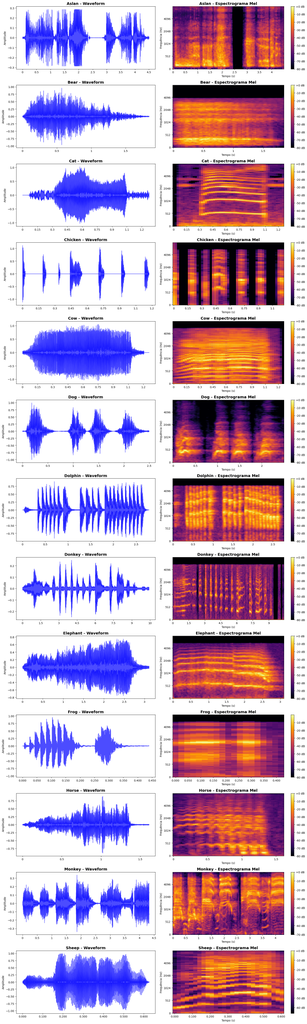

```python
import os
import numpy as np
import pandas as pd
import matplotlib.pyplot as plt
import librosa
import librosa.display
import warnings

warnings.filterwarnings('ignore')
plt.style.use('default')

DATA_ROOT_LOCAL = r"C:\Users\berto\OneDrive\Documentos\neural networks\dados_animal_temp\Animal-Soundprepros"
CLASSES = [d for d in os.listdir(DATA_ROOT_LOCAL) if os.path.isdir(os.path.join(DATA_ROOT_LOCAL, d))]
CLASSES.sort()

print(f" Total de Classes para Visualizar: {len(CLASSES)}")
print(f"Lista: {CLASSES}")

if len(CLASSES) == 0:
    print(" Nenhuma pasta encontrada.")
    exit()

print("\nGerando painel visual (Aguarde, processando áudios)...")


fig_height = 4 * len(CLASSES)
plt.figure(figsize=(16, fig_height))

for i, label in enumerate(CLASSES):
    class_path = os.path.join(DATA_ROOT_LOCAL, label)

    files = [f for f in os.listdir(class_path) if f.lower().endswith('.wav')]

    if not files:
        continue

    sample_file = files[0] # 1° exemplo
    full_path = os.path.join(class_path, sample_file)

    y, sr = librosa.load(full_path)

    ax1 = plt.subplot(len(CLASSES), 2, 2*i + 1)
    librosa.display.waveshow(y, sr=sr, alpha=0.7, color='blue')
    ax1.set_title(f"{label} - Waveform", fontsize=14, fontweight='bold')
    ax1.set_xlabel("")
    ax1.set_ylabel("Amplitude")


    ax2 = plt.subplot(len(CLASSES), 2, 2*i + 2)
    S = librosa.feature.melspectrogram(y=y, sr=sr, n_mels=128, fmax=8000)
    S_dB = librosa.power_to_db(S, ref=np.max)

    img = librosa.display.specshow(S_dB, x_axis='time', y_axis='mel', sr=sr, fmax=8000, ax=ax2, cmap='inferno')
    fig = plt.gcf()
    cbar = fig.colorbar(img, ax=ax2, format='%+2.0f dB')
    ax2.set_title(f"{label} - Espectrograma Mel", fontsize=14, fontweight='bold')
    ax2.set_xlabel("Tempo (s)")
    ax2.set_ylabel("Frequência (Hz)")

plt.tight_layout()
plt.show()
```

```
 Arquivos encontrados: 650
 Classes: ['Aslan' 'Bear' 'Cat' 'Chicken' 'Cow' 'Dog' 'Dolphin' 'Donkey' 'Elephant'
 'Frog' 'Horse' 'Monkey' 'Sheep']
   -> Processando 0/650...
   -> Processando 100/650...
   -> Processando 200/650...
   -> Processando 300/650...
   -> Processando 400/650...
   -> Processando 500/650...
   -> Processando 600/650...
 Total de amostras (com Augmentation): 1950

PASSO 4: Treinando o Modelo (20 Épocas)...

==================================================
RELATÓRIO FINAL DE PERFORMANCE
==================================================
 Acurácia de TREINO: 98.72%
 Acurácia de TESTE : 93.59%
--------------------------------------------------
Gerando visualizações...
```

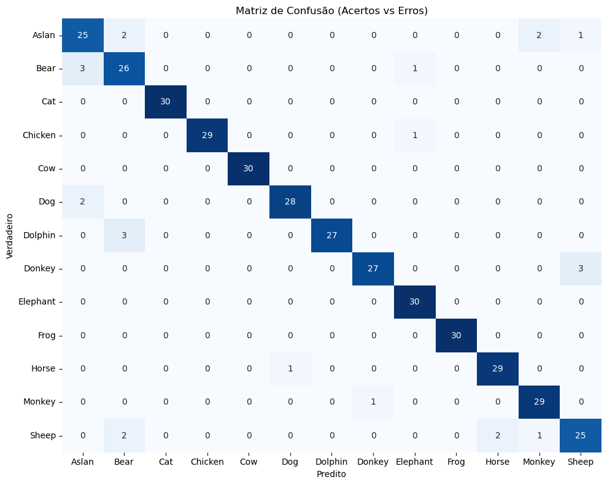

```
 TABELA DETALHADA POR ANIMAL
          Precisão  Recall  F1-Score Qtd
Aslan         0.83    0.83      0.83  30
Bear          0.79    0.87      0.83  30
Cat           1.00    1.00      1.00  30
Chicken       1.00    0.97      0.98  30
Cow           1.00    1.00      1.00  30
Dog           0.97    0.93      0.95  30
Dolphin       1.00    0.90      0.95  30
Donkey        0.96    0.90      0.93  30
Elephant      0.94    1.00      0.97  30
Frog          1.00    1.00      1.00  30
Horse         0.94    0.97      0.95  30
Monkey        0.91    0.97      0.94  30
Sheep         0.86    0.83      0.85  30
accuracy      0.94    0.94      0.94
==================================================
```

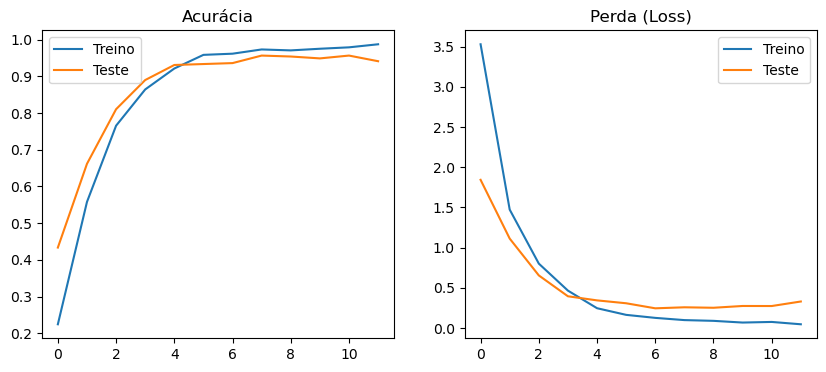

```python
import os
import sys
import warnings
import numpy as np
import pandas as pd
import matplotlib.pyplot as plt
import seaborn as sns
import soundfile as sf
import librosa
from sklearn.model_selection import train_test_split
from sklearn.preprocessing import LabelEncoder
from sklearn.metrics import confusion_matrix, classification_report

# Configuração do TensorFlow e Avisos
os.environ['TF_CPP_MIN_LOG_LEVEL'] = '3'
warnings.filterwarnings('ignore') # Ignora avisos de áudio curto/deprecated

import tensorflow as tf
tf.get_logger().setLevel('ERROR')

from tensorflow.keras.models import Sequential
from tensorflow.keras.layers import Dense, Dropout, Conv2D, MaxPooling2D, Flatten
from tensorflow.keras.utils import to_categorical
from tensorflow.keras.callbacks import EarlyStopping


# --- DEFINIÇÕES DE CAMINHO ---
DATA_ROOT_LOCAL = r"C:\Users\berto\OneDrive\Documentos\neural networks\dados_animal_temp\Animal-Soundprepros"
N_MFCC = 40
MAX_PADDING_LEN = 80


data = []

if not os.path.exists(DATA_ROOT_LOCAL):
    print(f" Pasta não encontrada: {DATA_ROOT_LOCAL}")
    sys.exit()

class_folders = [d for d in os.listdir(DATA_ROOT_LOCAL) if os.path.isdir(os.path.join(DATA_ROOT_LOCAL, d))]

if not class_folders:
    print(" Nenhuma classe encontrada.")
    sys.exit()

# Varredura
for class_label in class_folders:
    class_path = os.path.join(DATA_ROOT_LOCAL, class_label)
    for filename in os.listdir(class_path):
        if filename.lower().endswith('.wav'):
            data.append({
                'full_path': os.path.join(class_path, filename),
                'label': class_label
            })

df_files = pd.DataFrame(data)

if len(df_files) == 0:
    sys.exit()

print(f" Arquivos encontrados: {len(df_files)}")
print(f" Classes: {df_files['label'].unique()}")

## extração de features e data augmentation

def extract_features(file_path):
    extracted = []
    try:
        # Carrega áudio
        with warnings.catch_warnings():
            warnings.simplefilter("ignore")
            audio, sample_rate = sf.read(file_path, dtype='float32')

        # Garante Mono
        if audio.ndim > 1: audio = np.mean(audio, axis=1)

        # Função auxiliar de MFCC
        def get_mfcc(y):
            mfcc = librosa.feature.mfcc(y=y, sr=sample_rate, n_mfcc=N_MFCC)
            # Padronização de tamanho (Padding/Truncate)
            if mfcc.shape[1] > MAX_PADDING_LEN:
                mfcc = mfcc[:, :MAX_PADDING_LEN]
            else:
                pad_width = MAX_PADDING_LEN - mfcc.shape[1]
                mfcc = np.pad(mfcc, ((0, 0), (0, pad_width)), mode='constant')
            return mfcc.T

        # 1. Original
        extracted.append(get_mfcc(audio))

        # 2. Ruído (Noise)
        noise = audio + (0.005 * np.random.uniform()) * np.random.normal(size=audio.shape)
        extracted.append(get_mfcc(noise))

        # 3. Pitch Shift (Opcional - se der erro ele ignora)
        try:
            pitch = librosa.effects.pitch_shift(audio, sr=sample_rate, n_steps=np.random.uniform(-2, 2))
            extracted.append(get_mfcc(pitch))
        except: pass

    except Exception: return None
    return extracted

features = []
labels = []
total = len(df_files)

# Loop de processamento
for i, row in enumerate(df_files.itertuples()):
    if i % 100 == 0: print(f"   -> Processando {i}/{total}...")

    results = extract_features(row.full_path)
    if results:
        for feat in results:
            features.append(feat)
            labels.append(row.label)

# Conversão para Arrays
X = np.array(features)
X = X.reshape(X.shape[0], MAX_PADDING_LEN, N_MFCC, 1)

le = LabelEncoder()
y_encoded = le.fit_transform(labels)
y_categorical = to_categorical(y_encoded)

# Divisão Treino/Teste (com balanceamento)
X_train, X_test, y_train, y_test = train_test_split(
    X,
    y_categorical,
    test_size=0.2,
    random_state=42,
    stratify=y_categorical # balanceamento
)

print(f" Total de amostras (com Augmentation): {X.shape[0]}")

## treinamento da cnn

print("\nPASSO 4: Treinando o Modelo (20 Épocas)...")

model = Sequential([
    Conv2D(32, (3, 3), activation='relu', input_shape=(MAX_PADDING_LEN, N_MFCC, 1)),
    MaxPooling2D((2, 2)),

    Conv2D(64, (3, 3), activation='relu'),
    MaxPooling2D((2, 2)),

    Flatten(),
    Dense(128, activation='relu'),
    Dropout(0.4),

    Dense(y_categorical.shape[1], activation='softmax')
])

model.compile(optimizer='adam', loss='categorical_crossentropy', metrics=['accuracy'])

# Treinamento
history = model.fit(
    X_train, y_train,
    epochs=20,
    batch_size=32,
    validation_data=(X_test, y_test),
    callbacks=[EarlyStopping(monitor='val_loss', patience=5, restore_best_weights=True)],
    verbose=1
)

### relatório final


print("\n" + "="*50)
print("RELATÓRIO FINAL DE PERFORMANCE")
print("="*50)

# Acurácia
y_pred_probs = model.predict(X_test, verbose=0)
y_pred_classes = np.argmax(y_pred_probs, axis=1)
y_true = np.argmax(y_test, axis=1)

_, test_acc = model.evaluate(X_test, y_test, verbose=0)
train_acc = history.history['accuracy'][-1]

print(f" Acurácia de TREINO: {train_acc*100:.2f}%")
print(f" Acurácia de TESTE : {test_acc*100:.2f}%")
print("-" * 50)

# Matriz de Confusão
print("Gerando visualizações...")
cm = confusion_matrix(y_true, y_pred_classes)

plt.figure(figsize=(10, 8))
sns.heatmap(cm,
            annot=True,
            fmt='d',
            cmap='Blues',
            cbar=False,
            xticklabels=le.classes_,
            yticklabels=le.classes_)

plt.title('Matriz de Confusão (Acertos vs Erros)')
plt.ylabel('Verdadeiro')
plt.xlabel('Predito')
plt.tight_layout()
plt.show()

print("\n TABELA DETALHADA POR ANIMAL")
report_dict = classification_report(y_true, y_pred_classes, target_names=le.classes_, output_dict=True)

df_report = pd.DataFrame(report_dict).transpose()
df_report = df_report.drop(['macro avg', 'weighted avg'], errors='ignore')
df_report.columns = ['Precisão', 'Recall', 'F1-Score', 'Qtd']
df_report['Qtd'] = df_report['Qtd'].astype(int).astype(str)
df_report.loc['accuracy', 'Qtd'] = ''
df_report = df_report.round(2)

print(df_report)
print("="*50)

plt.figure(figsize=(10, 4))
plt.subplot(1, 2, 1)
plt.plot(history.history['accuracy'], label='Treino')
plt.plot(history.history['val_accuracy'], label='Teste')
plt.title('Acurácia')
plt.legend()

plt.subplot(1, 2, 2)
plt.plot(history.history['loss'], label='Treino')
plt.plot(history.history['val_loss'], label='Teste')
plt.title('Perda (Loss)')
plt.legend()
plt.show()
```